# Comparison PacBio vs. Illumina tpm

Author

Marie-Claire Indilewitsch

Published

January 9, 2024

# Exploratory comparison PacBio (bambu) vs. Illumina (salmon) data

## Methods

The exploratory comparison of PacBio vs. Illumina data was performed in RStudio (R version 4.3.2 (2023-10-31 ucrt)).

First, the data was imported and preprocessed (see seperate import_processing.qmd). Hereby, the control sequences were filtered out and counts and transcripts-per-million (tpm) saved seperately for Illumina+Salmon (short read) data and PacBio+Bambu (long read) data. Further, the 16 different dataframes (8 for tpm, 8 for counts) were sorted to have the same order and saved in .rds files (bambu, salmon and metadata) which were then used for further analysis. Then a first direct exploratory analysis was performed to get an overview of the data.

### Exploratory analysis

The exploratory analysis was divided into a first direct comparison looking at the differences in the counts/tpm between Illumina+Salmon and PacBio+Bambu for all 4 NDR cutoffs (0.025, 0.05, 0.1, 0.2) and visualizing them with histograms, followed by the computation of correlations between the different samples of Illumina+Salmon and PacBio+Bambu also stratified by transcript length and lastly looking at the MDS plots. The whole analysis was performed for count data as well as tpm data but it was decided to keep the tpm in the report file as it is more representative when performing the stratification by length (further explained in discussion). But the count plots as well as all other tpm plots not shown in the following can be found in the file comparison_pacbio_illumina.qmd.

#### Differences Illumina+Salmon vs. PacBio+Bambu

First, the direct differences between the Illumina+Salmon and PacBio+Bambu dataframes were calculated and visualized using histograms to see how different the raw data is. The histograms were only plotted for the first column of the dataframe (sample 1) as plotting all columns would not lead to an increase in information.

#### Correlation Illumina+Salmon vs. PacBio+Bambu

Secondly, the correlation between Illumina+Salmon and PacBio+Bambu was looked at first not stratified by length and secondly, stratified by length on the transcript level (tpm) for all 4 NDR cutoffs. Hereby the samples were divided into 10 bins always portraying an interval of transcript length of 1000 (0-1000, 1000-2000 and so on). Thus, the bins do not have the same size. Both pearson and spearman correlation between all samples were performed and visualized in heatmaps but in the results we decided on showing only the spearman plots (explained in the discussion). For all 10 bins the correlations were summed up and shown in a scatter plot to see the effect of transcript length for all 4 NDR cutoffs.

## Results

### Load packages

```r
library(tidyverse)
library(viridis)
library(pheatmap)
library(ggplot2)
library(edgeR)
library(limma)
library(patchwork)
```

### Load data

The data is loaded from RDS-object files from bambu, salmon and the metadata (from import_processing.qmd). For each of the 4 NDR cutoffs (0.025, 0.05, 0.1, 0.2), two data frames exist containing the expression data (counts) as well as transcript-per-million (tpm) of the two different technologies used to obtain the data:

```
1. Illumina sequencing and Salmon quantification (short read)
2. PacBio sequencing and Bambu quantification (long read)
```

```r
df_list_bambu <- readRDS("bambu.rds")
df_list_salmon <- readRDS("salmon.rds")
df_list_meta <- readRDS("meta.rds")
```

```r
bambu_0.025 <- df_list_bambu$bambu_0.025_tpm
bambu_0.05 <- df_list_bambu$bambu_0.05_tpm
bambu_0.1 <- df_list_bambu$bambu_0.1_tpm
bambu_0.2 <- df_list_bambu$bambu_0.2_tpm

salmon_0.025 <- df_list_salmon$salmon_0.025_tpm
salmon_0.05 <- df_list_salmon$salmon_0.05_tpm
salmon_0.1 <- df_list_salmon$salmon_0.1_tpm
salmon_0.2 <- df_list_salmon$salmon_0.2_tpm

bambu_0.025_gene <- df_list_bambu$bambu_0.025_tpm_gene
bambu_0.05_gene <- df_list_bambu$bambu_0.05_tpm_gene
bambu_0.1_gene <- df_list_bambu$bambu_0.1_tpm_gene
bambu_0.2_gene <- df_list_bambu$bambu_0.2_tpm_gene

salmon_0.025_gene <- df_list_salmon$salmon_0.025_tpm_gene
salmon_0.05_gene <- df_list_salmon$salmon_0.05_tpm_gene
salmon_0.1_gene <- df_list_salmon$salmon_0.1_tpm_gene
salmon_0.2_gene <- df_list_salmon$salmon_0.2_tpm_gene

bambu_0.025_count <- df_list_bambu$bambu_0.025
bambu_0.05_count <- df_list_bambu$bambu_0.05
bambu_0.1_count <- df_list_bambu$bambu_0.1
bambu_0.2_count <- df_list_bambu$bambu_0.2

salmon_0.025_count <- df_list_salmon$salmon_0.025
salmon_0.05_count <- df_list_salmon$salmon_0.05
salmon_0.1_count <- df_list_salmon$salmon_0.1
salmon_0.2_count <- df_list_salmon$salmon_0.2

bambu_0.025_gene_count <- df_list_bambu$bambu_0.025_gene
bambu_0.05_gene_count <- df_list_bambu$bambu_0.05_gene
bambu_0.1_gene_count <- df_list_bambu$bambu_0.1_gene
bambu_0.2_gene_count <- df_list_bambu$bambu_0.2_gene

salmon_0.025_gene_count <- df_list_salmon$salmon_0.025_gene
salmon_0.05_gene_count <- df_list_salmon$salmon_0.05_gene
salmon_0.1_gene_count <- df_list_salmon$salmon_0.1_gene
salmon_0.2_gene_count <- df_list_salmon$salmon_0.2_gene

meta_samples <- df_list_meta$metadata
```

### Differences

The differences between Illumina+Salmon and PacBio+Bambu have been computed in a direct comparison and it was calculated how many percent had a difference smaller than 50 (just to get an overview of the raw differences).

```r
difference1 <- salmon_0.025 - bambu_0.025
nrow(salmon_0.025[which(rowSums(abs(difference1)) < 50), ])/nrow(salmon_0.025)
```

```
[1] 0.9232244
```

```r
difference2 <- salmon_0.05- bambu_0.05
nrow(salmon_0.05[which(rowSums(abs(difference2)) < 50), ])/nrow(salmon_0.05)
```

```
[1] 0.9232975
```

```r
difference3 <- salmon_0.1 - bambu_0.1
nrow(salmon_0.1[which(rowSums(abs(difference3)) < 50), ])/nrow(salmon_0.1)
```

```
[1] 0.9234513
```

```r
difference4 <- salmon_0.2 - bambu_0.2
nrow(salmon_0.2[which(rowSums(abs(difference4)) < 50), ])/nrow(salmon_0.2)
```

```
[1] 0.9238523
```

```r
difference1_gene <- salmon_0.025_gene- bambu_0.025_gene
nrow(salmon_0.025_gene[which(rowSums(abs(difference1_gene)) < 50), ])/nrow(salmon_0.025_gene)
```

```
[1] 0.8487736
```

```r
difference2_gene <- salmon_0.05_gene- bambu_0.05_gene
nrow(salmon_0.05_gene[which(rowSums(abs(difference2_gene)) < 50), ])/nrow(salmon_0.05_gene)
```

```
[1] 0.8491386
```

```r
difference3_gene <- salmon_0.1_gene - bambu_0.1_gene
nrow(salmon_0.1_gene[which(rowSums(abs(difference3_gene)) < 50), ])/nrow(salmon_0.1_gene)
```

```
[1] 0.8496814
```

```r
difference4_gene <- salmon_0.2_gene - bambu_0.2_gene
nrow(salmon_0.2_gene[which(rowSums(abs(difference4_gene)) < 50), ])/nrow(salmon_0.2_gene)
```

```
[1] 0.851743
```

On the transcript level the differences are under 50 for always around 92% of the transcripts for all the NDR cutoffs and for the gene level around 85% for all the NDR cutoffs.

### Histograms of differences

This was then visualized for always the first column. Here we only show the plots for the 0.025 and 0.05 cutoffs on transcript and gene level because all 8 histograms look almost the same. The rest can be seen in the comparison_pacbio_illumia.qmd file.

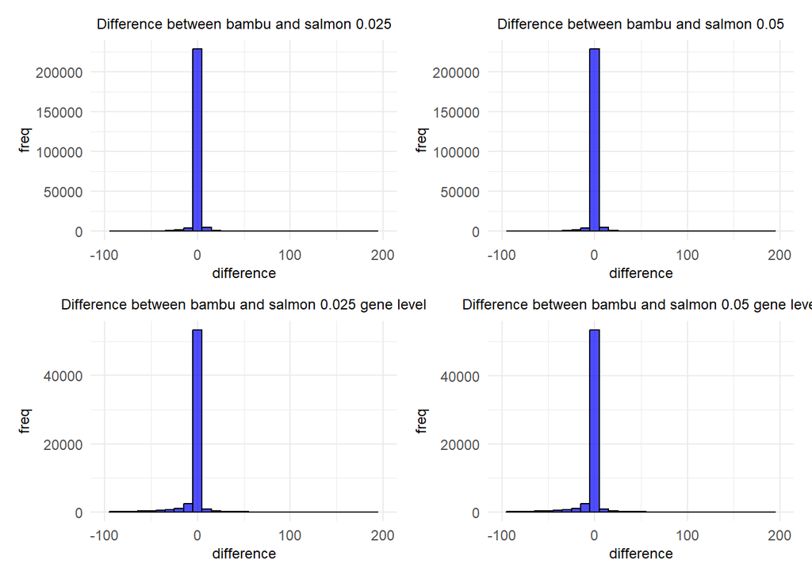

```r
#only always performed on first column

diff1 <- ggplot(difference1, aes(x = difference1[,1])) +
  geom_histogram(binwidth = 10, fill = "blue", color = "black", alpha = 0.7)+
  xlim(-100,200)+
  theme_minimal() +
  theme(plot.title = element_text(hjust = 0.5, size = 9), axis.title.x = element_text(size = 9), axis.title.y = element_text(size = 9)) +
  scale_color_viridis() +
  labs(title = "Difference between bambu and salmon 0.025", x = "difference", y = "freq")

diff2 <- ggplot(difference2, aes(x = difference2[,1])) +
  geom_histogram(binwidth = 10, fill = "blue", color = "black", alpha = 0.7)+
  xlim(-100,200)+
  theme_minimal() +
  theme(plot.title = element_text(hjust = 0.5, size = 9), axis.title.x = element_text(size = 9), axis.title.y = element_text(size = 9)) +
  scale_color_viridis() +
  labs(title = "Difference between bambu and salmon 0.05", x = "difference", y = "freq")

diff3 <- ggplot(difference1_gene, aes(x = difference1_gene[,1])) +
  geom_histogram(binwidth = 10, fill = "blue", color = "black", alpha = 0.7)+
  xlim(-100,200)+
  theme_minimal() +
  theme(plot.title = element_text(hjust = 0.5, size = 9), axis.title.x = element_text(size = 9), axis.title.y = element_text(size = 9)) +
  scale_color_viridis() +
  labs(title = "Difference between bambu and salmon 0.025 gene level", x = "difference", y = "freq")


diff4 <- ggplot(difference2_gene, aes(x = difference2_gene[,1])) +
  geom_histogram(binwidth = 10, fill = "blue", color = "black", alpha = 0.7)+
  xlim(-100,200)+
  theme_minimal() +
  theme(plot.title = element_text(hjust = 0.5, size = 9), axis.title.x = element_text(size = 9), axis.title.y = element_text(size = 9)) +
  scale_color_viridis() +
  labs(title = "Difference between bambu and salmon 0.05 gene level", x = "difference", y = "freq")

plot1 <- diff1 + diff2 + diff3 + diff4
plot1
```

As one can see, the most differences are around 0 (highest bar) with small bars around it. Thus, when just looking at the raw data the difference between Illumina+Salmon and PacBio+Bambu is small.

### Correlation and stratification by length

Next, the correlation between Illumina+Salmon and PacBio+Bambu was computed. For that, first the transcript lengths were exported as well as their distribution looked at to be able to divide them into sections for the stratification by transcript length.

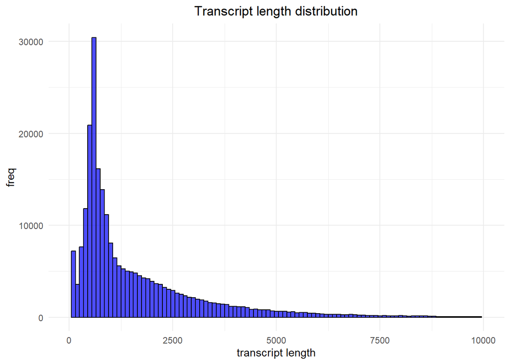

```r
#get length and filter by it
samples <- list.files("data/")
samples <- samples[grep(pattern = "0.025_salmon", x = samples)]


file <- paste0("data/", samples[1], "/", "quant.sf")
quant <- read.csv(file, sep = "\t", header = T)
length <- quant$Length

#distribution of lengths
ggplot(quant, aes(x = Length)) +
  geom_histogram(binwidth = 100, fill = "blue", color = "black", alpha = 0.7)+
  xlim(0,10000)+
  theme_minimal() +
  theme(plot.title = element_text(hjust = 0.5)) +
  scale_color_viridis() +
  labs(title = "Transcript length distribution", x = "transcript length", y = "freq")
```

```r
#dividing length into subsets based on plotted distribution
quant_below_1000 <- quant[quant$Length < 1000, ]
quant_1000_2000 <- quant[quant$Length >= 1000 & quant$Length < 2000, ]
quant_2000_3000 <- quant[quant$Length >= 2000 & quant$Length < 3000, ]
quant_3000_4000 <- quant[quant$Length >= 3000 & quant$Length < 4000, ]
quant_4000_5000 <- quant[quant$Length >= 4000 & quant$Length < 5000, ]
quant_5000_6000 <- quant[quant$Length >= 5000 & quant$Length < 6000, ]
quant_6000_7000 <- quant[quant$Length >= 6000 & quant$Length < 7000, ]
quant_7000_8000 <- quant[quant$Length >= 7000 & quant$Length < 8000, ]
quant_8000_9000 <- quant[quant$Length >= 8000 & quant$Length < 9000, ]
quant_9000_10000 <- quant[quant$Length >= 9000 & quant$Length < 10000, ]
```

As seen in the above plot, most transcripts have a length between 0 and around 2000 and at around 10000 almost no transcripts can be found. So, we decided on dividing the lengths into intervals of 1000 from 0 to 10000. Here it is of note, that the intervals do not contain the same amount of transcripts so the bins have different frequencies.

So first, the correlation not stratified by length was plotted. We performed both pearson- and spearman-correlation but we will only show one pearson plot here and only the first two NDR cutoffs for demonstration purposes (this will be talked about in the discussion).

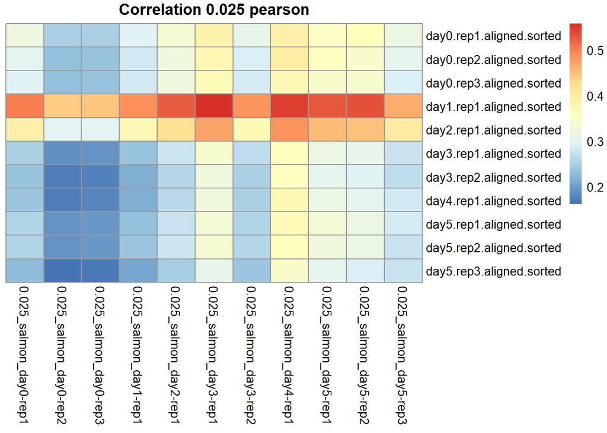

```r
#correlation not stratified by length

#pearson
cor_0.025 <- cor(bambu_0.025, salmon_0.025)
pheatmap(cor_0.025, cluster_rows = FALSE, cluster_cols = FALSE, main="Correlation 0.025 pearson")
```

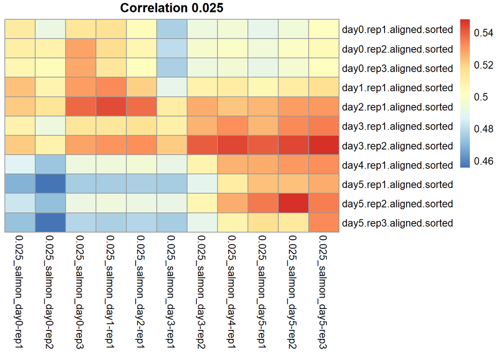

```r
# spearman
cor_0.025_sp <- cor(bambu_0.025, salmon_0.025, method = 'spearman')
cor_0.05_sp <- cor(bambu_0.05, salmon_0.05, method = 'spearman')
cor_0.025_gene_sp <- cor(bambu_0.025_gene, salmon_0.025_gene, method = 'spearman')
cor_0.05_gene_sp <- cor(bambu_0.05_gene, salmon_0.05_gene, method = 'spearman')


heat1 <- pheatmap(cor_0.025_sp, cluster_rows = FALSE, cluster_cols = FALSE, main = "Correlation 0.025")
```

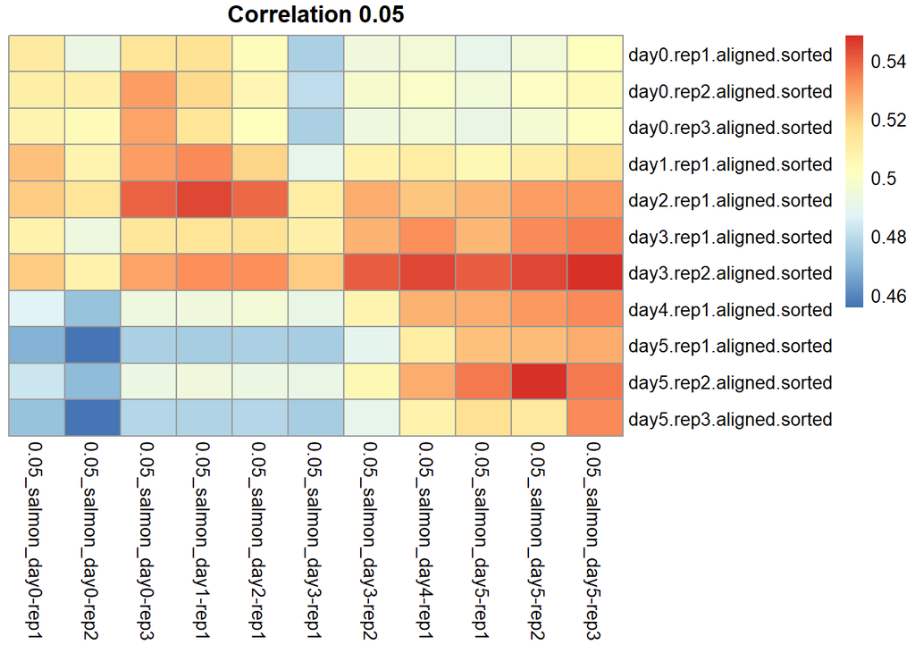

```r
heat2 <- pheatmap(cor_0.05_sp, cluster_rows = FALSE, cluster_cols = FALSE, main = "Correlation 0.05")
```

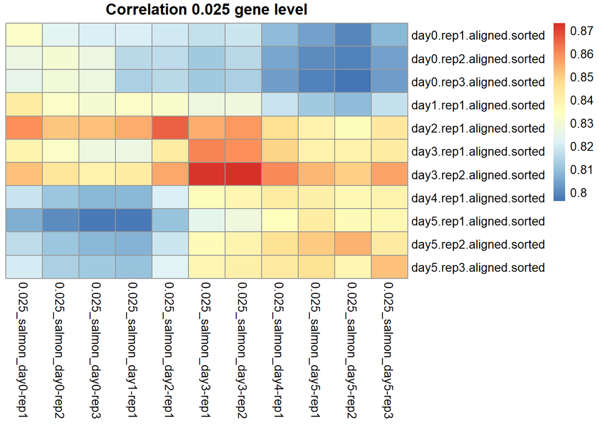

```r
heat3 <- pheatmap(cor_0.025_gene_sp, cluster_rows = FALSE, cluster_cols = FALSE, main = "Correlation 0.025 gene level")
```

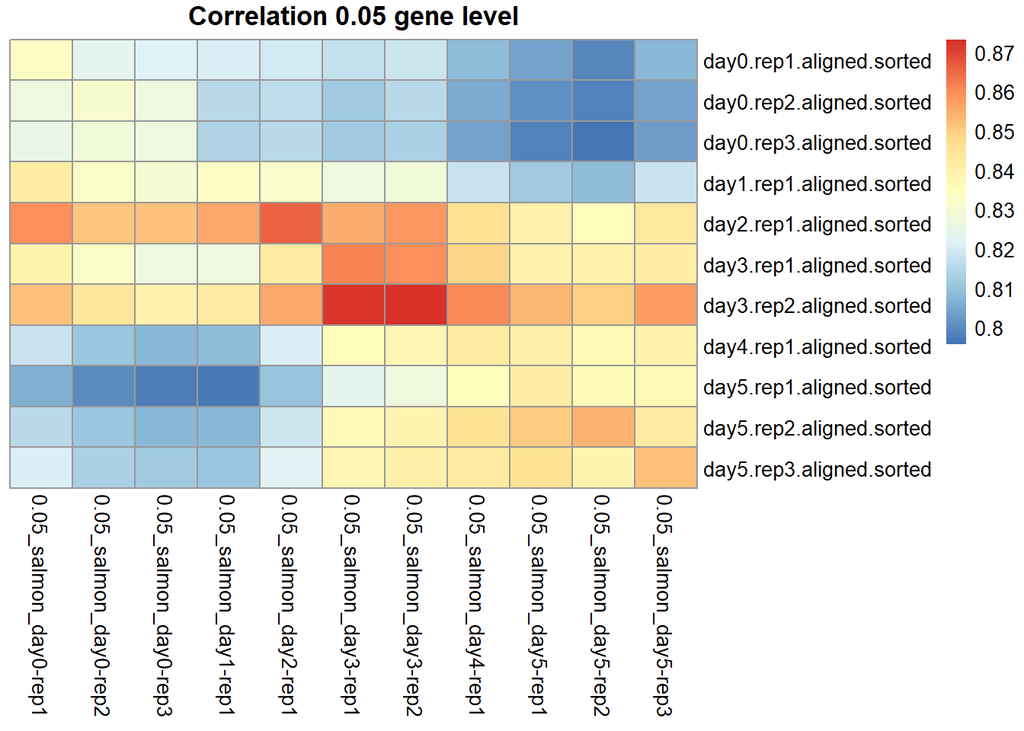

```r
heat4 <- pheatmap(cor_0.05_gene_sp, cluster_rows = FALSE, cluster_cols = FALSE, main = "Correlation 0.05 gene level")
```

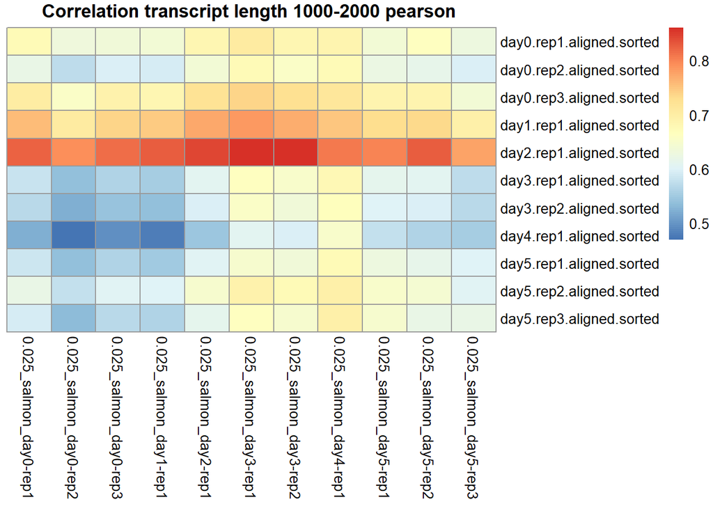

```r
#0.025
bambu_0.025_below_1000 <- subset(bambu_0.025, rownames(bambu_0.025) %in% quant_below_1000$Name)
salmon_0.025_below_1000 <- subset(salmon_0.025, rownames(salmon_0.025) %in% quant_below_1000$Name)

bambu_0.025_1000_2000 <- subset(bambu_0.025, rownames(bambu_0.025) %in% quant_1000_2000$Name)
salmon_0.025_1000_2000 <- subset(salmon_0.025, rownames(salmon_0.025) %in% quant_1000_2000$Name)

bambu_0.025_2000_3000 <- subset(bambu_0.025, rownames(bambu_0.025) %in% quant_2000_3000$Name)
salmon_0.025_2000_3000 <- subset(salmon_0.025, rownames(salmon_0.025) %in% quant_2000_3000$Name)

bambu_0.025_3000_4000 <- subset(bambu_0.025, rownames(bambu_0.025) %in% quant_3000_4000$Name)
salmon_0.025_3000_4000 <- subset(salmon_0.025, rownames(salmon_0.025) %in% quant_3000_4000$Name)

bambu_0.025_4000_5000 <- subset(bambu_0.025, rownames(bambu_0.025) %in% quant_4000_5000$Name)
salmon_0.025_4000_5000 <- subset(salmon_0.025, rownames(salmon_0.025) %in% quant_4000_5000$Name)

bambu_0.025_5000_6000 <- subset(bambu_0.025, rownames(bambu_0.025) %in% quant_5000_6000$Name)
salmon_0.025_5000_6000 <- subset(salmon_0.025, rownames(salmon_0.025) %in% quant_5000_6000$Name)

bambu_0.025_6000_7000 <- subset(bambu_0.025, rownames(bambu_0.025) %in% quant_6000_7000$Name)
salmon_0.025_6000_7000 <- subset(salmon_0.025, rownames(salmon_0.025) %in% quant_6000_7000$Name)

bambu_0.025_7000_8000 <- subset(bambu_0.025, rownames(bambu_0.025) %in% quant_7000_8000$Name)
salmon_0.025_7000_8000 <- subset(salmon_0.025, rownames(salmon_0.025) %in% quant_7000_8000$Name)

bambu_0.025_8000_9000 <- subset(bambu_0.025, rownames(bambu_0.025) %in% quant_8000_9000$Name)
salmon_0.025_8000_9000 <- subset(salmon_0.025, rownames(salmon_0.025) %in% quant_8000_9000$Name)

bambu_0.025_9000_10000 <- subset(bambu_0.025, rownames(bambu_0.025) %in% quant_9000_10000$Name)
salmon_0.025_9000_10000 <- subset(salmon_0.025, rownames(salmon_0.025) %in% quant_9000_10000$Name)




cor_0.025_below_1000 <- cor(bambu_0.025_below_1000, salmon_0.025_below_1000)
cor_0.025_1000_2000 <- cor(bambu_0.025_1000_2000, salmon_0.025_1000_2000)
cor_0.025_2000_3000 <- cor(bambu_0.025_2000_3000, salmon_0.025_2000_3000)
cor_0.025_3000_4000 <- cor(bambu_0.025_3000_4000, salmon_0.025_3000_4000)
cor_0.025_4000_5000 <- cor(bambu_0.025_4000_5000, salmon_0.025_4000_5000)

cor_0.025_5000_6000 <- cor(bambu_0.025_5000_6000, salmon_0.025_5000_6000)
cor_0.025_6000_7000 <- cor(bambu_0.025_6000_7000, salmon_0.025_6000_7000)
cor_0.025_7000_8000 <- cor(bambu_0.025_7000_8000, salmon_0.025_7000_8000)
cor_0.025_8000_9000 <- cor(bambu_0.025_8000_9000, salmon_0.025_8000_9000)
cor_0.025_9000_10000 <- cor(bambu_0.025_9000_10000, salmon_0.025_9000_10000)

sum1 <- sum(as.matrix(cor_0.025_below_1000))
sum2 <- sum(as.matrix(cor_0.025_1000_2000))
sum3 <- sum(as.matrix(cor_0.025_2000_3000))
sum4 <- sum(as.matrix(cor_0.025_3000_4000))
sum5 <- sum(as.matrix(cor_0.025_4000_5000))
sum6 <- sum(as.matrix(cor_0.025_5000_6000))
sum7 <- sum(as.matrix(cor_0.025_6000_7000))
sum8 <- sum(as.matrix(cor_0.025_7000_8000))
sum9 <- sum(as.matrix(cor_0.025_8000_9000))
sum10 <- sum(as.matrix(cor_0.025_9000_10000))


pheatmap(cor_0.025_1000_2000, cluster_rows = FALSE, cluster_cols = FALSE, main = "Correlation transcript length 1000-2000 pearson ")
```

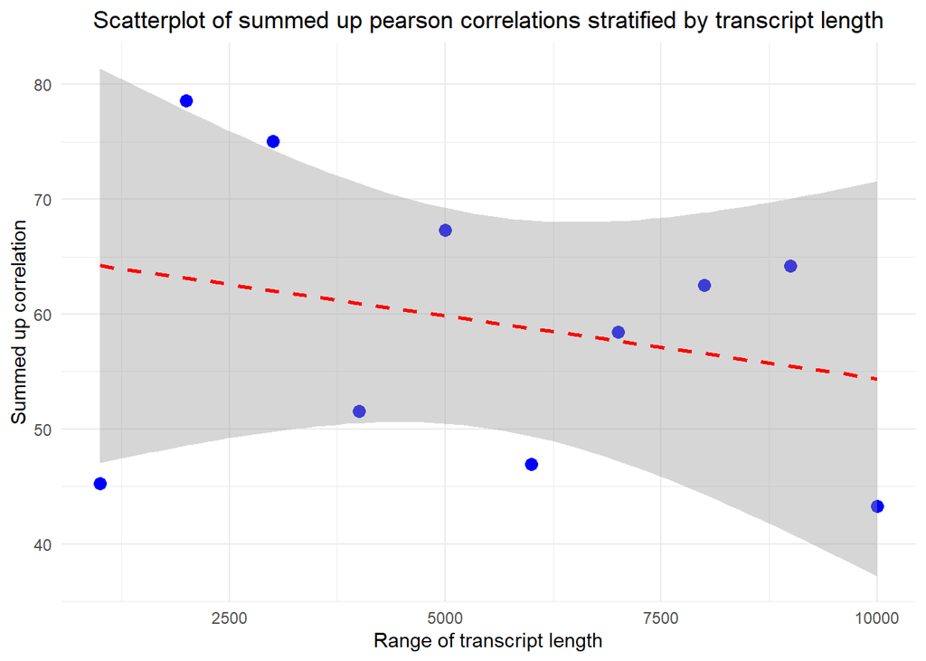

```r
sums_df <- data.frame(
  Range = c(1000,2000,3000,4000,5000,6000,7000,8000,9000,10000),
  Sum = c(sum1, sum2, sum3, sum4, sum5, sum6, sum7, sum8, sum9, sum10)
)


ggplot(sums_df, aes(x = Range, y = Sum)) +
  geom_point(color = "blue", size = 3) +
  labs(title = "Scatterplot of summed up pearson correlations stratified by transcript length", x = "Range of transcript length", y = "Summed up correlation")+
  theme_minimal() +
  theme(plot.title = element_text(hjust = 0.5)) +
  scale_color_viridis() +
  stat_smooth(method="lm", col = "red", lty = 2)
```

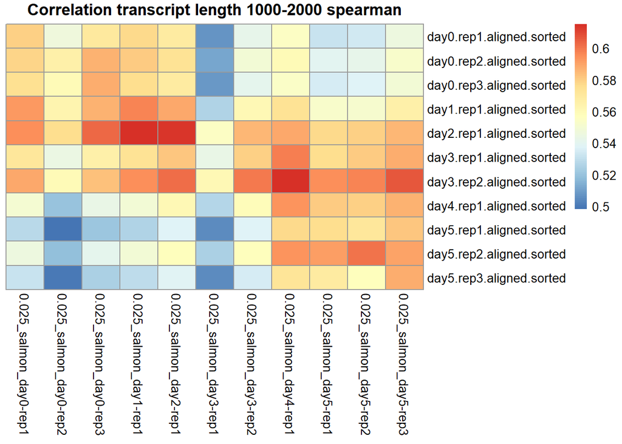

```r
cor_0.025_below_1000_sp <- cor(bambu_0.025_below_1000, salmon_0.025_below_1000, method = 'spearman')
cor_0.025_1000_2000_sp <- cor(bambu_0.025_1000_2000, salmon_0.025_1000_2000, method = 'spearman')
cor_0.025_2000_3000_sp <- cor(bambu_0.025_2000_3000, salmon_0.025_2000_3000, method = 'spearman')
cor_0.025_3000_4000_sp <- cor(bambu_0.025_3000_4000, salmon_0.025_3000_4000, method = 'spearman')
cor_0.025_4000_5000_sp <- cor(bambu_0.025_4000_5000, salmon_0.025_4000_5000, method = 'spearman')

cor_0.025_5000_6000_sp <- cor(bambu_0.025_5000_6000, salmon_0.025_5000_6000, method = 'spearman')
cor_0.025_6000_7000_sp <- cor(bambu_0.025_6000_7000, salmon_0.025_6000_7000, method = 'spearman')
cor_0.025_7000_8000_sp <- cor(bambu_0.025_7000_8000, salmon_0.025_7000_8000, method = 'spearman')
cor_0.025_8000_9000_sp <- cor(bambu_0.025_8000_9000, salmon_0.025_8000_9000, method = 'spearman')
cor_0.025_9000_10000_sp <- cor(bambu_0.025_9000_10000, salmon_0.025_9000_10000, method = 'spearman')

sum1_sp <- sum(as.matrix(cor_0.025_below_1000_sp))
sum2_sp <- sum(as.matrix(cor_0.025_1000_2000_sp))
sum3_sp <- sum(as.matrix(cor_0.025_2000_3000_sp))
sum4_sp <- sum(as.matrix(cor_0.025_3000_4000_sp))
sum5_sp <- sum(as.matrix(cor_0.025_4000_5000_sp))
sum6_sp <- sum(as.matrix(cor_0.025_5000_6000_sp))
sum7_sp <- sum(as.matrix(cor_0.025_6000_7000_sp))
sum8_sp <- sum(as.matrix(cor_0.025_7000_8000_sp))
sum9_sp <- sum(as.matrix(cor_0.025_8000_9000_sp))
sum10_sp <- sum(as.matrix(cor_0.025_9000_10000_sp))


#pheatmap(cor_0.025_below_1000_sp, cluster_rows = FALSE, cluster_cols = FALSE)
pheatmap(cor_0.025_1000_2000_sp, cluster_rows = FALSE, cluster_cols = FALSE,  main = "Correlation transcript length 1000-2000 spearman")
```

```r
#pheatmap(cor_0.025_2000_3000_sp, cluster_rows = FALSE, cluster_cols = FALSE)
#pheatmap(cor_0.025_3000_4000_sp, cluster_rows = FALSE, cluster_cols = FALSE)
#pheatmap(cor_0.025_4000_5000_sp, cluster_rows = FALSE, cluster_cols = FALSE)
#pheatmap(cor_0.025_5000_6000_sp, cluster_rows = FALSE, cluster_cols = FALSE)
#pheatmap(cor_0.025_6000_7000_sp, cluster_rows = FALSE, cluster_cols = FALSE)
#pheatmap(cor_0.025_7000_8000_sp, cluster_rows = FALSE, cluster_cols = FALSE)
#pheatmap(cor_0.025_8000_9000_sp, cluster_rows = FALSE, cluster_cols = FALSE)
#pheatmap(cor_0.025_9000_10000_sp, cluster_rows = FALSE, cluster_cols = FALSE)

sums_df_sp <- data.frame(
  Range = c(1000,2000,3000,4000,5000,6000,7000,8000,9000,10000),
  Sum = c(sum1_sp, sum2_sp, sum3_sp, sum4_sp, sum5_sp, sum6_sp, sum7_sp, sum8_sp, sum9_sp, sum10_sp)
)


scatter1 <- ggplot(sums_df_sp, aes(x = Range, y = Sum)) +
  geom_point(color = "blue", size = 3) +
  labs(title = "0.025", x = "Range", y = "Summed up correlation")+
  theme_minimal() +
  theme(plot.title = element_text(hjust = 0.5, size = 9), axis.title.x = element_text(size = 9), axis.title.y = element_text(size = 9)) +
  scale_color_viridis() +
  stat_smooth(method="lm", col = "red", lty = 2)
```

The pearson plots do not look like usual heatmap as the day 2 - rep 1 - bambu is highly correlated with all samples of salmon and the rest of the correlations seem quite low. Also the scatterplot is widely spread and one can see no clear trend of the summed up correlation as it is jumping up and down. When observing the 0.025 heatmap with spearman correlation one sees most of the samples being highly correlated with itself (or the replicates) and a bit clearer the highly correlated diagonal usually seen in heatmaps.

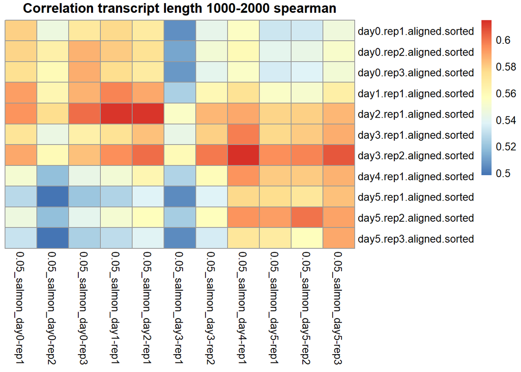

```r
#0.05
bambu_0.05_below_1000 <- subset(bambu_0.05, rownames(bambu_0.05) %in% quant_below_1000$Name)
salmon_0.05_below_1000 <- subset(salmon_0.05, rownames(salmon_0.05) %in% quant_below_1000$Name)

bambu_0.05_1000_2000 <- subset(bambu_0.05, rownames(bambu_0.05) %in% quant_1000_2000$Name)
salmon_0.05_1000_2000 <- subset(salmon_0.05, rownames(salmon_0.05) %in% quant_1000_2000$Name)

bambu_0.05_2000_3000 <- subset(bambu_0.05, rownames(bambu_0.05) %in% quant_2000_3000$Name)
salmon_0.05_2000_3000 <- subset(salmon_0.05, rownames(salmon_0.05) %in% quant_2000_3000$Name)

bambu_0.05_3000_4000 <- subset(bambu_0.05, rownames(bambu_0.05) %in% quant_3000_4000$Name)
salmon_0.05_3000_4000 <- subset(salmon_0.05, rownames(salmon_0.05) %in% quant_3000_4000$Name)

bambu_0.05_4000_5000 <- subset(bambu_0.05, rownames(bambu_0.05) %in% quant_4000_5000$Name)
salmon_0.05_4000_5000 <- subset(salmon_0.05, rownames(salmon_0.05) %in% quant_4000_5000$Name)

bambu_0.05_5000_6000 <- subset(bambu_0.05, rownames(bambu_0.05) %in% quant_5000_6000$Name)
salmon_0.05_5000_6000 <- subset(salmon_0.05, rownames(salmon_0.05) %in% quant_5000_6000$Name)

bambu_0.05_6000_7000 <- subset(bambu_0.05, rownames(bambu_0.05) %in% quant_6000_7000$Name)
salmon_0.05_6000_7000 <- subset(salmon_0.05, rownames(salmon_0.05) %in% quant_6000_7000$Name)

bambu_0.05_7000_8000 <- subset(bambu_0.05, rownames(bambu_0.05) %in% quant_7000_8000$Name)
salmon_0.05_7000_8000 <- subset(salmon_0.05, rownames(salmon_0.05) %in% quant_7000_8000$Name)

bambu_0.05_8000_9000 <- subset(bambu_0.05, rownames(bambu_0.05) %in% quant_8000_9000$Name)
salmon_0.05_8000_9000 <- subset(salmon_0.05, rownames(salmon_0.05) %in% quant_8000_9000$Name)

bambu_0.05_9000_10000 <- subset(bambu_0.05, rownames(bambu_0.05) %in% quant_9000_10000$Name)
salmon_0.05_9000_10000 <- subset(salmon_0.05, rownames(salmon_0.05) %in% quant_9000_10000$Name)




cor_0.05_below_1000 <- cor(bambu_0.05_below_1000, salmon_0.05_below_1000, method = 'spearman')
cor_0.05_1000_2000 <- cor(bambu_0.05_1000_2000, salmon_0.05_1000_2000, method = 'spearman')
cor_0.05_2000_3000 <- cor(bambu_0.05_2000_3000, salmon_0.05_2000_3000, method = 'spearman')
cor_0.05_3000_4000 <- cor(bambu_0.05_3000_4000, salmon_0.05_3000_4000, method = 'spearman')
cor_0.05_4000_5000 <- cor(bambu_0.05_4000_5000, salmon_0.05_4000_5000, method = 'spearman')

cor_0.05_5000_6000 <- cor(bambu_0.05_5000_6000, salmon_0.05_5000_6000, method = 'spearman')
cor_0.05_6000_7000 <- cor(bambu_0.05_6000_7000, salmon_0.05_6000_7000, method = 'spearman')
cor_0.05_7000_8000 <- cor(bambu_0.05_7000_8000, salmon_0.05_7000_8000, method = 'spearman')
cor_0.05_8000_9000 <- cor(bambu_0.05_8000_9000, salmon_0.05_8000_9000, method = 'spearman')
cor_0.05_9000_10000 <- cor(bambu_0.05_9000_10000, salmon_0.05_9000_10000, method = 'spearman')


#pheatmap(cor_0.05_below_1000, cluster_rows = FALSE, cluster_cols = FALSE)
pheatmap(cor_0.05_1000_2000, cluster_rows = FALSE, cluster_cols = FALSE,  main = "Correlation transcript length 1000-2000 spearman")
```

```r
#pheatmap(cor_0.05_2000_3000, cluster_rows = FALSE, cluster_cols = FALSE)
#pheatmap(cor_0.05_3000_4000, cluster_rows = FALSE, cluster_cols = FALSE)
#pheatmap(cor_0.05_4000_5000, cluster_rows = FALSE, cluster_cols = FALSE)
#pheatmap(cor_0.05_5000_6000, cluster_rows = FALSE, cluster_cols = FALSE)
#pheatmap(cor_0.05_6000_7000, cluster_rows = FALSE, cluster_cols = FALSE)
#pheatmap(cor_0.05_7000_8000, cluster_rows = FALSE, cluster_cols = FALSE)
#pheatmap(cor_0.05_8000_9000, cluster_rows = FALSE, cluster_cols = FALSE)
#pheatmap(cor_0.05_9000_10000, cluster_rows = FALSE, cluster_cols = FALSE)

sum1_0.05 <- sum(as.matrix(cor_0.05_below_1000))
sum2_0.05 <- sum(as.matrix(cor_0.05_1000_2000))
sum3_0.05 <- sum(as.matrix(cor_0.05_2000_3000))
sum4_0.05 <- sum(as.matrix(cor_0.05_3000_4000))
sum5_0.05 <- sum(as.matrix(cor_0.05_4000_5000))
sum6_0.05 <- sum(as.matrix(cor_0.05_5000_6000))
sum7_0.05 <- sum(as.matrix(cor_0.05_6000_7000))
sum8_0.05 <- sum(as.matrix(cor_0.05_7000_8000))
sum9_0.05 <- sum(as.matrix(cor_0.05_8000_9000))
sum10_0.05 <- sum(as.matrix(cor_0.05_9000_10000))
sums_df_0.05 <- data.frame(
  Range = c(1000,2000,3000,4000,5000,6000,7000,8000,9000,10000),
  Sum = c(sum1_0.05, sum2_0.05, sum3_0.05, sum4_0.05, sum5_0.05, sum6_0.05, sum7_0.05, sum8_0.05, sum9_0.05, sum10_0.05)
)


scatter2 <- ggplot(sums_df_0.05, aes(x = Range, y = Sum)) +
  geom_point(color = "blue", size = 3) +
  labs(title = "0.05", x = "Range", y = "Summed up correlation")+
  theme_minimal() +
  theme(plot.title = element_text(hjust = 0.5, size = 9), axis.title.x = element_text(size = 9), axis.title.y = element_text(size = 9)) +
  scale_color_viridis() +
  stat_smooth(method="lm", col = "red", lty = 2)
```

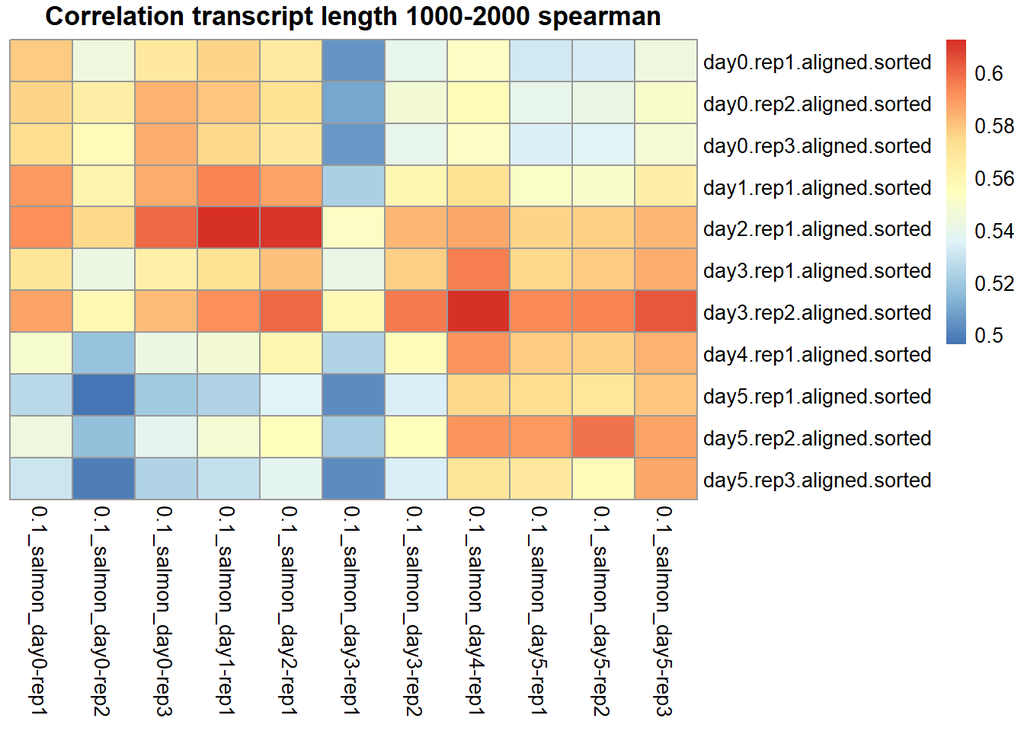

```r
#0.1
bambu_0.1_below_1000 <- subset(bambu_0.1, rownames(bambu_0.1) %in% quant_below_1000$Name)
salmon_0.1_below_1000 <- subset(salmon_0.1, rownames(salmon_0.1) %in% quant_below_1000$Name)

bambu_0.1_1000_2000 <- subset(bambu_0.1, rownames(bambu_0.1) %in% quant_1000_2000$Name)
salmon_0.1_1000_2000 <- subset(salmon_0.1, rownames(salmon_0.1) %in% quant_1000_2000$Name)

bambu_0.1_2000_3000 <- subset(bambu_0.1, rownames(bambu_0.1) %in% quant_2000_3000$Name)
salmon_0.1_2000_3000 <- subset(salmon_0.1, rownames(salmon_0.1) %in% quant_2000_3000$Name)

bambu_0.1_3000_4000 <- subset(bambu_0.1, rownames(bambu_0.1) %in% quant_3000_4000$Name)
salmon_0.1_3000_4000 <- subset(salmon_0.1, rownames(salmon_0.1) %in% quant_3000_4000$Name)

bambu_0.1_4000_5000 <- subset(bambu_0.1, rownames(bambu_0.1) %in% quant_4000_5000$Name)
salmon_0.1_4000_5000 <- subset(salmon_0.1, rownames(salmon_0.1) %in% quant_4000_5000$Name)

bambu_0.1_5000_6000 <- subset(bambu_0.1, rownames(bambu_0.1) %in% quant_5000_6000$Name)
salmon_0.1_5000_6000 <- subset(salmon_0.1, rownames(salmon_0.1) %in% quant_5000_6000$Name)

bambu_0.1_6000_7000 <- subset(bambu_0.1, rownames(bambu_0.1) %in% quant_6000_7000$Name)
salmon_0.1_6000_7000 <- subset(salmon_0.1, rownames(salmon_0.1) %in% quant_6000_7000$Name)

bambu_0.1_7000_8000 <- subset(bambu_0.1, rownames(bambu_0.1) %in% quant_7000_8000$Name)
salmon_0.1_7000_8000 <- subset(salmon_0.1, rownames(salmon_0.1) %in% quant_7000_8000$Name)

bambu_0.1_8000_9000 <- subset(bambu_0.1, rownames(bambu_0.1) %in% quant_8000_9000$Name)
salmon_0.1_8000_9000 <- subset(salmon_0.1, rownames(salmon_0.1) %in% quant_8000_9000$Name)

bambu_0.1_9000_10000 <- subset(bambu_0.1, rownames(bambu_0.1) %in% quant_9000_10000$Name)
salmon_0.1_9000_10000 <- subset(salmon_0.1, rownames(salmon_0.1) %in% quant_9000_10000$Name)




cor_0.1_below_1000 <- cor(bambu_0.1_below_1000, salmon_0.1_below_1000, method = 'spearman')
cor_0.1_1000_2000 <- cor(bambu_0.1_1000_2000, salmon_0.1_1000_2000, method = 'spearman')
cor_0.1_2000_3000 <- cor(bambu_0.1_2000_3000, salmon_0.1_2000_3000, method = 'spearman')
cor_0.1_3000_4000 <- cor(bambu_0.1_3000_4000, salmon_0.1_3000_4000, method = 'spearman')
cor_0.1_4000_5000 <- cor(bambu_0.1_4000_5000, salmon_0.1_4000_5000, method = 'spearman')

cor_0.1_5000_6000 <- cor(bambu_0.1_5000_6000, salmon_0.1_5000_6000, method = 'spearman')
cor_0.1_6000_7000 <- cor(bambu_0.1_6000_7000, salmon_0.1_6000_7000, method = 'spearman')
cor_0.1_7000_8000 <- cor(bambu_0.1_7000_8000, salmon_0.1_7000_8000, method = 'spearman')
cor_0.1_8000_9000 <- cor(bambu_0.1_8000_9000, salmon_0.1_8000_9000, method = 'spearman')
cor_0.1_9000_10000 <- cor(bambu_0.1_9000_10000, salmon_0.1_9000_10000, method = 'spearman')


#pheatmap(cor_0.1_below_1000, cluster_rows = FALSE, cluster_cols = FALSE)
pheatmap(cor_0.1_1000_2000, cluster_rows = FALSE, cluster_cols = FALSE,  main = "Correlation transcript length 1000-2000 spearman")
```

```r
#pheatmap(cor_0.1_2000_3000, cluster_rows = FALSE, cluster_cols = FALSE)
#pheatmap(cor_0.1_3000_4000, cluster_rows = FALSE, cluster_cols = FALSE)
#pheatmap(cor_0.1_4000_5000, cluster_rows = FALSE, cluster_cols = FALSE)
#pheatmap(cor_0.1_5000_6000, cluster_rows = FALSE, cluster_cols = FALSE)
#pheatmap(cor_0.1_6000_7000, cluster_rows = FALSE, cluster_cols = FALSE)
#pheatmap(cor_0.1_7000_8000, cluster_rows = FALSE, cluster_cols = FALSE)
#pheatmap(cor_0.1_8000_9000, cluster_rows = FALSE, cluster_cols = FALSE)
#pheatmap(cor_0.1_9000_10000, cluster_rows = FALSE, cluster_cols = FALSE)

sum1_0.1 <- sum(as.matrix(cor_0.1_below_1000))
sum2_0.1 <- sum(as.matrix(cor_0.1_1000_2000))
sum3_0.1 <- sum(as.matrix(cor_0.1_2000_3000))
sum4_0.1 <- sum(as.matrix(cor_0.1_3000_4000))
sum5_0.1 <- sum(as.matrix(cor_0.1_4000_5000))
sum6_0.1 <- sum(as.matrix(cor_0.1_5000_6000))
sum7_0.1 <- sum(as.matrix(cor_0.1_6000_7000))
sum8_0.1 <- sum(as.matrix(cor_0.1_7000_8000))
sum9_0.1 <- sum(as.matrix(cor_0.1_8000_9000))
sum10_0.1 <- sum(as.matrix(cor_0.1_9000_10000))
sums_df_0.1 <- data.frame(
  Range = c(1000,2000,3000,4000,5000,6000,7000,8000,9000,10000),
  Sum = c(sum1_0.1, sum2_0.1, sum3_0.1, sum4_0.1, sum5_0.1, sum6_0.1, sum7_0.1, sum8_0.1, sum9_0.1, sum10_0.1)
)


scatter3 <- ggplot(sums_df_0.1, aes(x = Range, y = Sum)) +
  geom_point(color = "blue", size = 3) +
  labs(title = "0.1", x = "Range", y = "Summed up correlation")+
  theme_minimal() +
  theme(plot.title = element_text(hjust = 0.5, size = 9), axis.title.x = element_text(size = 9), axis.title.y = element_text(size = 9)) +
  scale_color_viridis()+
  stat_smooth(method="lm", col = "red", lty = 2)
```

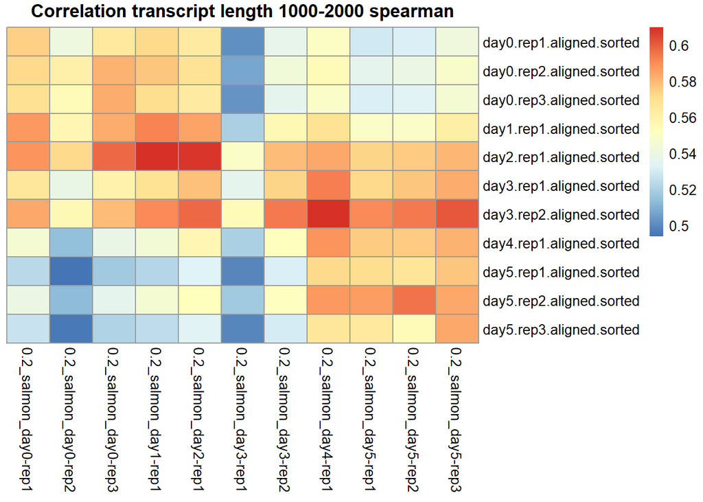

```r
#0.2
bambu_0.2_below_1000 <- subset(bambu_0.2, rownames(bambu_0.2) %in% quant_below_1000$Name)
salmon_0.2_below_1000 <- subset(salmon_0.2, rownames(salmon_0.2) %in% quant_below_1000$Name)

bambu_0.2_1000_2000 <- subset(bambu_0.2, rownames(bambu_0.2) %in% quant_1000_2000$Name)
salmon_0.2_1000_2000 <- subset(salmon_0.2, rownames(salmon_0.2) %in% quant_1000_2000$Name)

bambu_0.2_2000_3000 <- subset(bambu_0.2, rownames(bambu_0.2) %in% quant_2000_3000$Name)
salmon_0.2_2000_3000 <- subset(salmon_0.2, rownames(salmon_0.2) %in% quant_2000_3000$Name)

bambu_0.2_3000_4000 <- subset(bambu_0.2, rownames(bambu_0.2) %in% quant_3000_4000$Name)
salmon_0.2_3000_4000 <- subset(salmon_0.2, rownames(salmon_0.2) %in% quant_3000_4000$Name)

bambu_0.2_4000_5000 <- subset(bambu_0.2, rownames(bambu_0.2) %in% quant_4000_5000$Name)
salmon_0.2_4000_5000 <- subset(salmon_0.2, rownames(salmon_0.2) %in% quant_4000_5000$Name)

bambu_0.2_5000_6000 <- subset(bambu_0.2, rownames(bambu_0.2) %in% quant_5000_6000$Name)
salmon_0.2_5000_6000 <- subset(salmon_0.2, rownames(salmon_0.2) %in% quant_5000_6000$Name)

bambu_0.2_6000_7000 <- subset(bambu_0.2, rownames(bambu_0.2) %in% quant_6000_7000$Name)
salmon_0.2_6000_7000 <- subset(salmon_0.2, rownames(salmon_0.2) %in% quant_6000_7000$Name)

bambu_0.2_7000_8000 <- subset(bambu_0.2, rownames(bambu_0.2) %in% quant_7000_8000$Name)
salmon_0.2_7000_8000 <- subset(salmon_0.2, rownames(salmon_0.2) %in% quant_7000_8000$Name)

bambu_0.2_8000_9000 <- subset(bambu_0.2, rownames(bambu_0.2) %in% quant_8000_9000$Name)
salmon_0.2_8000_9000 <- subset(salmon_0.2, rownames(salmon_0.2) %in% quant_8000_9000$Name)

bambu_0.2_9000_10000 <- subset(bambu_0.2, rownames(bambu_0.2) %in% quant_9000_10000$Name)
salmon_0.2_9000_10000 <- subset(salmon_0.2, rownames(salmon_0.2) %in% quant_9000_10000$Name)




cor_0.2_below_1000 <- cor(bambu_0.2_below_1000, salmon_0.2_below_1000, method = 'spearman')
cor_0.2_1000_2000 <- cor(bambu_0.2_1000_2000, salmon_0.2_1000_2000, method = 'spearman')
cor_0.2_2000_3000 <- cor(bambu_0.2_2000_3000, salmon_0.2_2000_3000, method = 'spearman')
cor_0.2_3000_4000 <- cor(bambu_0.2_3000_4000, salmon_0.2_3000_4000, method = 'spearman')
cor_0.2_4000_5000 <- cor(bambu_0.2_4000_5000, salmon_0.2_4000_5000, method = 'spearman')
cor_0.2_5000_6000 <- cor(bambu_0.2_5000_6000, salmon_0.2_5000_6000, method = 'spearman')
cor_0.2_6000_7000 <- cor(bambu_0.2_6000_7000, salmon_0.2_6000_7000, method = 'spearman')
cor_0.2_7000_8000 <- cor(bambu_0.2_7000_8000, salmon_0.2_7000_8000, method = 'spearman')
cor_0.2_8000_9000 <- cor(bambu_0.2_8000_9000, salmon_0.2_8000_9000, method = 'spearman')
cor_0.2_9000_10000 <- cor(bambu_0.2_9000_10000, salmon_0.2_9000_10000, method = 'spearman')

#pheatmap(cor_0.2_below_1000, cluster_rows = FALSE, cluster_cols = FALSE)
pheatmap(cor_0.2_1000_2000, cluster_rows = FALSE, cluster_cols = FALSE,  main = "Correlation transcript length 1000-2000 spearman")
```

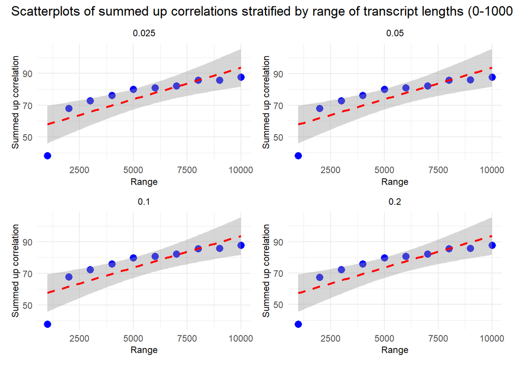

```r
#pheatmap(cor_0.2_2000_3000, cluster_rows = FALSE, cluster_cols = FALSE)
#pheatmap(cor_0.2_3000_4000, cluster_rows = FALSE, cluster_cols = FALSE)
#pheatmap(cor_0.2_4000_5000, cluster_rows = FALSE, cluster_cols = FALSE)
#pheatmap(cor_0.2_5000_6000, cluster_rows = FALSE, cluster_cols = FALSE)
#pheatmap(cor_0.2_6000_7000, cluster_rows = FALSE, cluster_cols = FALSE)
#pheatmap(cor_0.2_7000_8000, cluster_rows = FALSE, cluster_cols = FALSE)
#pheatmap(cor_0.2_8000_9000, cluster_rows = FALSE, cluster_cols = FALSE)
#pheatmap(cor_0.2_9000_10000, cluster_rows = FALSE, cluster_cols = FALSE)

sum1_0.2 <- sum(as.matrix(cor_0.2_below_1000))
sum2_0.2 <- sum(as.matrix(cor_0.2_1000_2000))
sum3_0.2 <- sum(as.matrix(cor_0.2_2000_3000))
sum4_0.2 <- sum(as.matrix(cor_0.2_3000_4000))
sum5_0.2 <- sum(as.matrix(cor_0.2_4000_5000))
sum6_0.2 <- sum(as.matrix(cor_0.2_5000_6000))
sum7_0.2 <- sum(as.matrix(cor_0.2_6000_7000))
sum8_0.2 <- sum(as.matrix(cor_0.2_7000_8000))
sum9_0.2 <- sum(as.matrix(cor_0.2_8000_9000))
sum10_0.2 <- sum(as.matrix(cor_0.2_9000_10000))
sums_df_0.2 <- data.frame(
  Range = c(1000,2000,3000,4000,5000,6000,7000,8000,9000,10000),
  Sum = c(sum1_0.2, sum2_0.2, sum3_0.2, sum4_0.2, sum5_0.2, sum6_0.2, sum7_0.2, sum8_0.2, sum9_0.2, sum10_0.2)
)


scatter4 <- ggplot(sums_df_0.2, aes(x = Range, y = Sum)) +
  geom_point(color = "blue", size = 3) +
  labs(title = "0.2", x = "Range", y = "Summed up correlation")+
  theme_minimal() +
  theme(plot.title = element_text(hjust = 0.5, size = 9), axis.title.x = element_text(size = 9), axis.title.y = element_text(size = 9)) +
  scale_color_viridis()+
  stat_smooth(method="lm", col = "red", lty = 2)

scatter_total <- scatter1 + scatter2 + scatter3 + scatter4
scatter_total <- scatter_total +
  plot_layout(nrow = 2, byrow = TRUE) +
  plot_annotation(title = "Scatterplots of summed up correlations stratified by range of transcript lengths (0-10000)")
scatter_total
```

The rest of the heatmaps for the other cutoffs (0.05, 0.1, 0.2) look very similar to the 0.025 heatmap. Looking at the scatterplots of summed up correlations stratified by range of transcript lengths they also look almost the same between the different cutoffs. One can observe the clear trend that with a higher transcript length the correlation is also higher but for very small transcript lengths (<1000) the correlation is very low.

### MDS

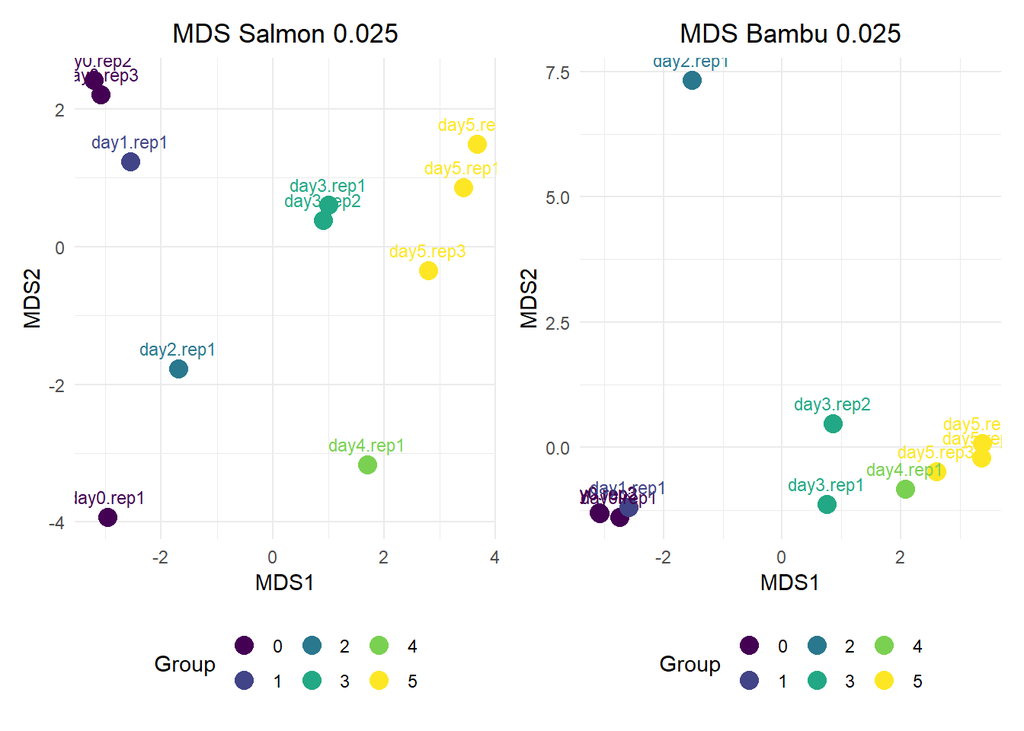

```r
group <- factor(df_list_meta$metadata$time)

## Salmon 0.025
y_salmon_0.025 <- DGEList(counts = salmon_0.025_count, group = group)

mds <- plotMDS(y_salmon_0.025, plot = FALSE) # uses plotMDS.DGEList

df <- data.frame(
  MDS1 = mds$x,
  MDS2 = mds$y,
  group = group,
  shortname = df_list_meta$metadata$condition
)
mds1 <- ggplot(df, aes(x = MDS1, y = MDS2, colour = group)) +
  geom_point(size = 4) +
  geom_text(aes(label = shortname), vjust = -1, size = 3) +
  theme_minimal() +
  theme(plot.title = element_text(hjust = 0.5), legend.position = "bottom") +
  labs(title = "MDS Salmon 0.025", color = "Group") +
  scale_color_viridis_d()

## Bambu 0.025
y_bambu_0.025 <- DGEList(counts = bambu_0.025_count, group = group)

mds <- plotMDS(y_bambu_0.025, plot = FALSE) # uses plotMDS.DGEList

df <- data.frame(
  MDS1 = mds$x,
  MDS2 = mds$y,
  group = group,
  shortname = df_list_meta$metadata$condition
)
mds2 <- ggplot(df, aes(x = MDS1, y = MDS2, colour = group)) +
  geom_point(size = 4) +
  geom_text(aes(label = shortname), vjust = -1, size = 3) +
  theme_minimal() +
  theme(plot.title = element_text(hjust = 0.5), legend.position = "bottom") +
  labs(title = "MDS Bambu 0.025", color = "Group") +
  scale_color_viridis_d()


## Salmon 0.05
y_salmon_0.05 <- DGEList(counts = salmon_0.05_count, group = group)

mds <- plotMDS(y_salmon_0.05, plot = FALSE) # uses plotMDS.DGEList

df <- data.frame(
  MDS1 = mds$x,
  MDS2 = mds$y,
  group = group,
  shortname = df_list_meta$metadata$condition
)
mds3 <- ggplot(df, aes(x = MDS1, y = MDS2, colour = group)) +
  geom_point(size = 4) +
  geom_text(aes(label = shortname), vjust = -1, size = 3) +
  theme_minimal() +
  theme(plot.title = element_text(hjust = 0.5), legend.position = "bottom") +
  labs(title = "MDS Salmon 0.05", color = "Group") +
  scale_color_viridis_d()

## Bambu 0.05
y_bambu_0.05 <- DGEList(counts = bambu_0.05_count, group = group)

mds <- plotMDS(y_bambu_0.05, plot = FALSE) # uses plotMDS.DGEList

df <- data.frame(
  MDS1 = mds$x,
  MDS2 = mds$y,
  group = group,
  shortname = df_list_meta$metadata$condition
)
mds4 <- ggplot(df, aes(x = MDS1, y = MDS2, colour = group)) +
  geom_point(size = 4) +
  geom_text(aes(label = shortname), vjust = -1, size = 3) +
  theme_minimal() +
  theme(plot.title = element_text(hjust = 0.5), legend.position = "bottom") +
  labs(title = "MDS Bambu 0.05", color = "Group") +
  scale_color_viridis_d()

## Salmon 0.1
y_salmon_0.1 <- DGEList(counts = salmon_0.1_count, group = group)

mds <- plotMDS(y_salmon_0.1, plot = FALSE) # uses plotMDS.DGEList

df <- data.frame(
  MDS1 = mds$x,
  MDS2 = mds$y,
  group = group,
  shortname = df_list_meta$metadata$condition
)
mds5<- ggplot(df, aes(x = MDS1, y = MDS2, colour = group)) +
  geom_point(size = 4) +
  geom_text(aes(label = shortname), vjust = -1, size = 3) +
  theme_minimal() +
  theme(plot.title = element_text(hjust = 0.5)) +
  labs(title = "MDS Salmon 0.1", color = "Group") +
  scale_color_viridis_d()

## Bambu 0.1
y_bambu_0.1 <- DGEList(counts = bambu_0.1_count, group = group)

mds <- plotMDS(y_bambu_0.1, plot = FALSE) # uses plotMDS.DGEList

df <- data.frame(
  MDS1 = mds$x,
  MDS2 = mds$y,
  group = group,
  shortname = df_list_meta$metadata$condition
)
mds6 <- ggplot(df, aes(x = MDS1, y = MDS2, colour = group)) +
  geom_point(size = 4) +
  geom_text(aes(label = shortname), vjust = -1, size = 3) +
  theme_minimal() +
  theme(plot.title = element_text(hjust = 0.5)) +
  labs(title = "MDS Bambu 0.1", color = "Group") +
  scale_color_viridis_d()

## Salmon 0.2
y_salmon_0.2 <- DGEList(counts = salmon_0.2_count, group = group)

mds <- plotMDS(y_salmon_0.2, plot = FALSE) # uses plotMDS.DGEList

df <- data.frame(
  MDS1 = mds$x,
  MDS2 = mds$y,
  group = group,
  shortname = df_list_meta$metadata$condition
)
mds7 <- ggplot(df, aes(x = MDS1, y = MDS2, colour = group)) +
  geom_point(size = 4) +
  geom_text(aes(label = shortname), vjust = -1, size = 3) +
  theme_minimal() +
  theme(plot.title = element_text(hjust = 0.5)) +
  labs(title = "MDS Salmon 0.2", color = "Group") +
  scale_color_viridis_d()

## Bambu 0.2
y_bambu_0.2 <- DGEList(counts = bambu_0.2_count, group = group)

mds <- plotMDS(y_bambu_0.2, plot = FALSE) # uses plotMDS.DGEList

df <- data.frame(
  MDS1 = mds$x,
  MDS2 = mds$y,
  group = group,
  shortname = df_list_meta$metadata$condition
)
mds8 <- ggplot(df, aes(x = MDS1, y = MDS2, colour = group)) +
  geom_point(size = 4) +
  geom_text(aes(label = shortname), vjust = -1, size = 3) +
  theme_minimal() +
  theme(plot.title = element_text(hjust = 0.5)) +
  labs(title = "MDS Bambu 0.2", color = "Group") +
  scale_color_viridis_d()

mdstotal1 <- mds1 + mds2
mdstotal2 <- mds3 + mds4
mdstotal1
```

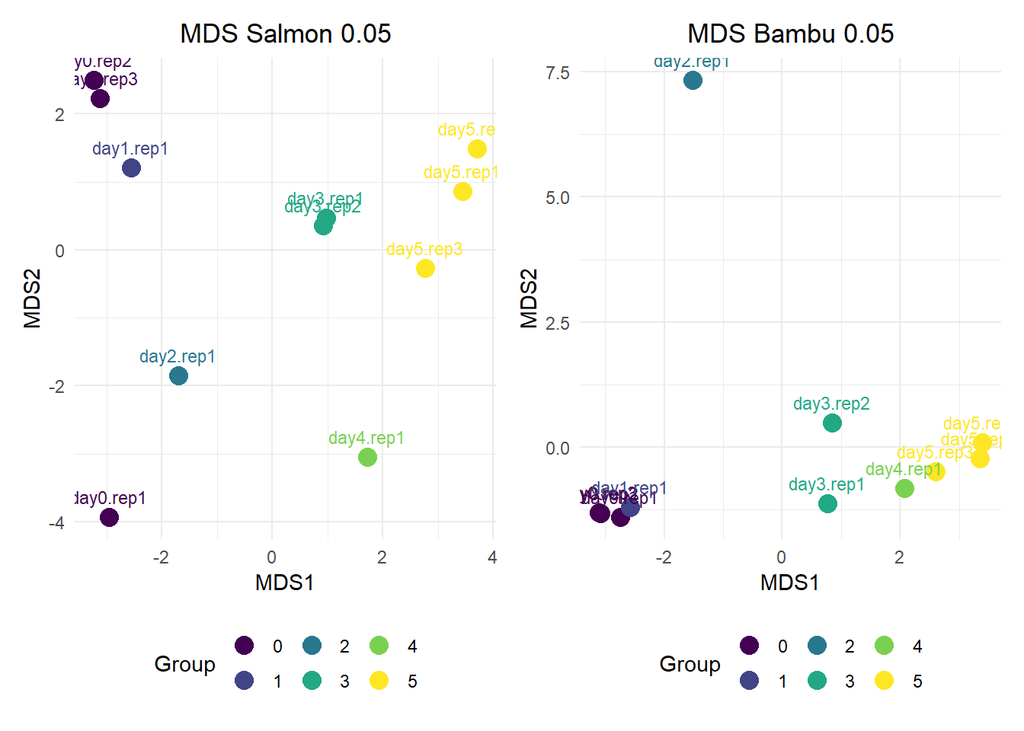

```r
mdstotal2
```

The MDS plots look very similiar between all the 4 NDR cutoffs. When comparing the MDS plots between Salmon and Bambu the MDS1 separation by day is almost the same with the MDS2 separation being a bit more different. In Bambu the replicated are grouped a bit closer together then in Salmon and fewer samples are above 0.

## Discussion

With the exploratory analysis of the data the goal was to get a first overview of both datasets as well as the differences in the raw data between Illumina+Salmon and PacBio+Bambu for all 4 different NDR cutoffs and correlations between the two methods stratified by length.

Firstly, the results for all 4 cutoffs are very similar which is why we decided to also keep in only the results for one/two different NDR cutoffs for this part of the report as we gain no extra information when including all cutoffs and this would take up too much space. The only small differences can be explained by the fact that the NDR cutoffs determine the number of newly detected genes which doesn’t have an effect on the comparison of both methods.

Secondly, we performed the analysis on count and tpm data but decided to keep in only the result for tpm as we stratify by transcipt length therefore making these results more interesting, also because the further analysis steps are also performed on tpm rather than the raw count data. For completeness the count results can be found in a separate file(comparison_pacbio_illumina.qmd).

### Differences

We wanted to further look at the differences between the Illumina data, so short read data produced by a thoroughly optimized and long-in-use method, and the long-read PacBio data, that has not been optimized well and is still suffering some biases. So we started with just looking at the difference in raw data. Looking at the percentages and the histograms the difference in raw data seems to be quite small the majority being <50 as well as the highest bar of the histograms being around 0. This was shown here only for the first column as all the oher columns look very similar (no information gain). This would suggest that the Illumina and PacBio raw dara seem to be quite similar with only minor deviations.

### Correlation and stratification by length

Next, we looked at the correlation between Illumina and PacBio data. We performed both pearson and spearman correlation. When looking at the pearson results compared to spearman they look very unusual. One can’t say that each sample is highest correlated with itself and some samples are highly correlated with all samples of all days (usually sample day 1 or 2) for both stratified and not stratified by length. Also, the scatterplot looks very unusual as for the different bins the summed up correlation is jumping up and down compared to heatmaps and scatterplots of spearman which look as expected. This can be explained by the fact that spearman correlation is more robust to outliers than spearman and doesn’t assume a linear relationship which works better with our data. So we decided to only focus on the plots produced by the spearman correlation.

The heatmaps for the length stratification again look similar between the 4 NDR cutoffs and show as expected highest correlation with their own sample between salmon and bambu as well as the replicates only with salmon-day3-rep1 standing out. This means that the individual samples between bambu and salmon do correlate well and are the most similar the their own sample in the other method and thus both methods seem to produce comparable results although the heatmaps and correlation aren’t as pronounced. This may be due to noise and outliers which even the spearman correlation isn’t robust to.

### MDS

The MDS plots look again the same for all 4 NDR cutoffs and are comparable between Illumina and PacBio. MDS1 separates the samples in both methods by days and MDS2 by replicates. For Salmon the replicates are more spread out than for Bambu but the overall trend is the same with the differences being explained by the difference in method again showing that the raw (in this case count data) is comparable between the both methods.

All in all, this first part of our project gave an overview over the differences in the raw data between Illumina and PacBio and showed that the data has its differences but seems to be quite comparable especially when looking at the raw data differences as well as the correlation with there still being difficulties in shorter transcript lengths.